# Projekt z eksploracji

## Cel badania

Celem badania jest zbudowanie modelu klasyfikującego, który na podstawie cech klinicznych będzie przewidywać czy pacjent z niewydolnością serca umrze w okresie obserwacji.

## Opis zbioru danych

`age` - wiek pacjenta

`anaemia` - zmienna binarna opisująca czy pacjent ma anemię, czyli czy liczba czerwonych krwinek jest zmniejszona

`creatinine_phosphokinase` - zmienna ilościowa oznaczająca poziom enzymu CPK (kinazy fosfokreatynowej) we krwi (mcg/l), jej wysoki poziom może sugerować niewydolność serca lub ranę

`diabetes` - zmienna binarna opisująca czy pacjent choruje na cukrzycę

`ejection_fraction` - procent objętości wypompowywanej krwi z komory serca w czasie skurczu

`high_blood_pressure` - zmienna binarna oznaczająca czy pacjent ma nadciśnienie

`platelets` - zmienna opisująca ilość płytek krwi u pacjenta

`sex` - zmienna binarna oznaczająca płeć pacjenta przyjmująca dwa poziomy:

- 0 - kobieta
- 1 - mężczyna

`serum_creatinine` - zmienna ilościowa opisująca poziom kreatyniny we krwi, jej wysoki poziom może sugerować zaburzenie czynności nerek

`serum_sodium` - zmienna ilościowa opisująca stężenie sodu we krwi, nieprawidłowe poziomy mogą wskazywać na niewydolność serca

`smoking` - zmienna binarna opisująca czy pacjent pali

`time` - zmienna ilościowa oznaczająca okres obserwacji pacjenta liczony w dniach

`death_event`- zmienna binarna czy pacjent zmarł w okresie obserwacji, również zmienna zależna przyjmująca dwa poziomy:

- 0 - pacjent przeżył
- 1 - pacjent nie przeżył

**Pokaż kod**

```r
flextable(head(heart)) %>%
  theme_zebra()
```

Table 1: Początkowe wartości ze zbioru

| age | anaemia | creatinine_phosphokinase | diabetes | ejection_fraction | high_blood_pressure | platelets | serum_creatinine | serum_sodium | sex | smoking | time | death_event |
| --- | --- | --- | --- | --- | --- | --- | --- | --- | --- | --- | --- | --- |
| 75 | 0 | 582 | 0 | 20 | 1 | 265,000 | 1.9 | 130 | 1 | 0 | 4 | 1 |
| 55 | 0 | 7,861 | 0 | 38 | 0 | 263,358 | 1.1 | 136 | 1 | 0 | 6 | 1 |
| 65 | 0 | 146 | 0 | 20 | 0 | 162,000 | 1.3 | 129 | 1 | 1 | 7 | 1 |
| 50 | 1 | 111 | 0 | 20 | 0 | 210,000 | 1.9 | 137 | 1 | 0 | 7 | 1 |
| 65 | 1 | 160 | 1 | 20 | 0 | 327,000 | 2.7 | 116 | 0 | 0 | 8 | 1 |
| 90 | 1 | 47 | 0 | 40 | 1 | 204,000 | 2.1 | 132 | 1 | 1 | 8 | 1 |

## Przygotowanie zbioru

Zbiór nie zawierał żadnych braków danych, jednakże konieczne było dostosowanie typów poszczególnych kolumn.

```
[1] 0
```

[output not shown]

## Wizualizacja zbioru

**Pokaż kod**

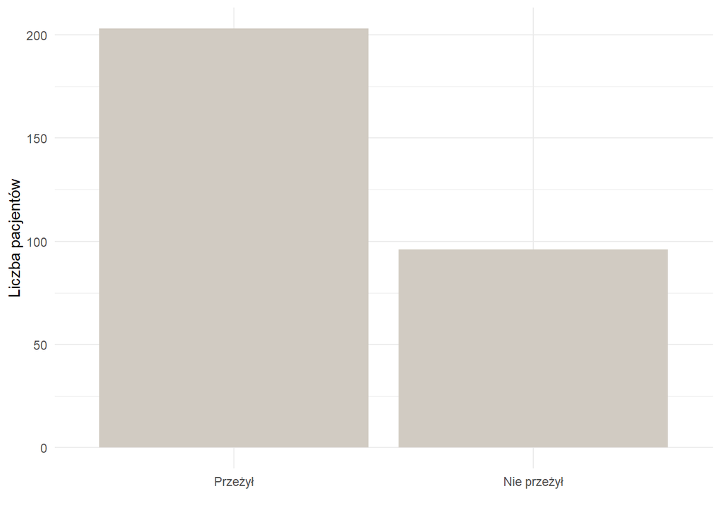

```r
heart %>%
  ggplot(aes(x = death_event)) +
  geom_bar(fill = "#D1CBC2") +
  labs(x = " ", y = "Liczba pacjentów") +
  scale_x_discrete(labels = c("0" = "Przeżył", "1" = "Nie przeżył")) +
  theme_minimal()
```

**Pokaż kod**

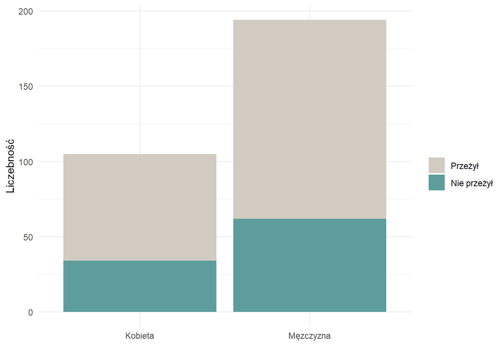

```r
heart %>%
  ggplot(aes(x = sex, fill = death_event)) +
  geom_bar() +
  labs(x = "", y = "Liczebność", fill = " ") +
  scale_fill_manual(labels = c("Przeżył", "Nie przeżył"), values = c("#D1CBC2", "#5D9E9C")) +
  scale_x_discrete(labels = c("0" = "Kobieta", "1" = "Męzczyzna")) +
  theme_minimal()
```

**Pokaż kod**

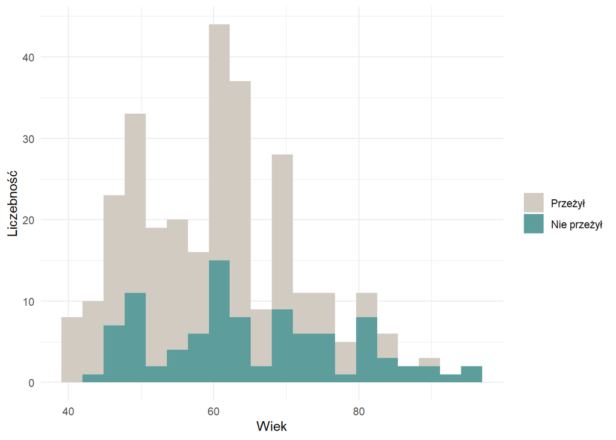

```r
heart %>%
  ggplot(aes(x = age, fill = death_event)) +
  geom_histogram(bins = 20) +
  labs(x = "Wiek", y = "Liczebność", fill = " ") +
  scale_fill_manual(labels = c("Przeżył", "Nie przeżył"), values = c("#D1CBC2", "#5D9E9C")) +
  theme_minimal()
```

**Pokaż kod**

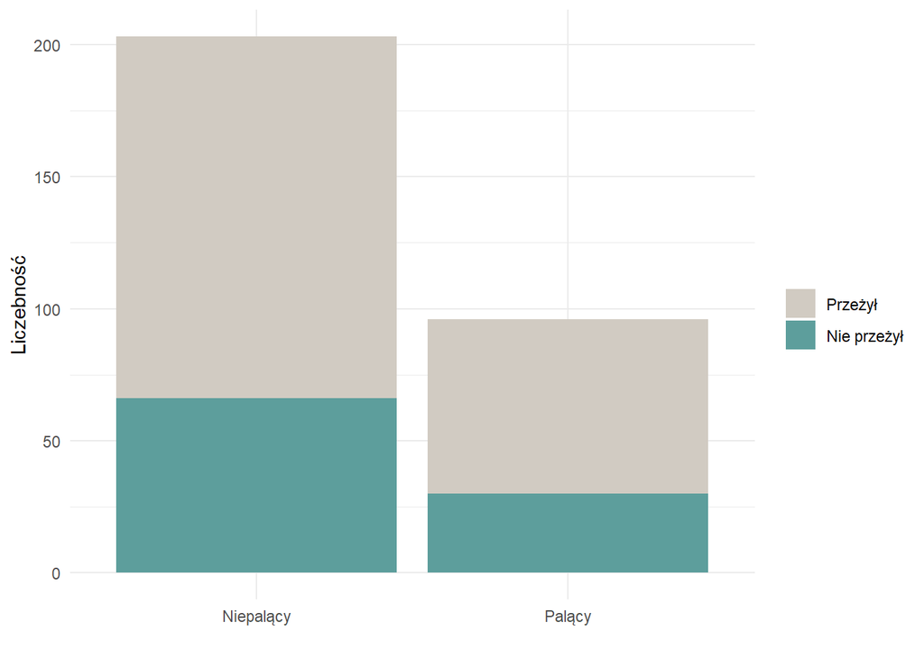

```r
heart %>%
  ggplot(aes(x = smoking, fill = death_event)) +
  geom_bar() +
  labs(x = "", y = "Liczebność", fill = " ") +
  scale_fill_manual(labels = c("Przeżył", "Nie przeżył"), values = c("#D1CBC2", "#5D9E9C")) +
  scale_x_discrete(labels = c("0" = "Niepalący", "1" = "Palący")) +
  theme_minimal()
```

**Pokaż kod**

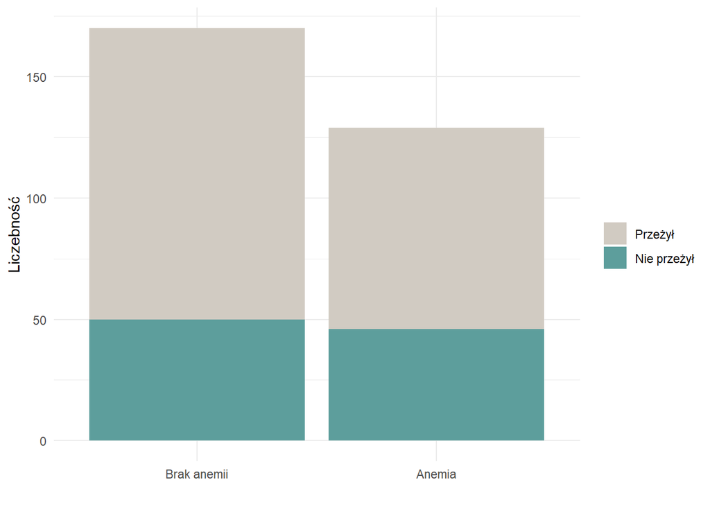

```r
heart %>%
  ggplot(aes(x = anaemia, fill = death_event)) +
  geom_bar() +
  labs(x = "", y = "Liczebność", fill = " ") +
  scale_fill_manual(labels = c("Przeżył", "Nie przeżył"), values = c("#D1CBC2", "#5D9E9C")) +
  scale_x_discrete(labels = c("0" = "Brak anemii", "1" = "Anemia")) +
  theme_minimal()
```

**Pokaż kod**

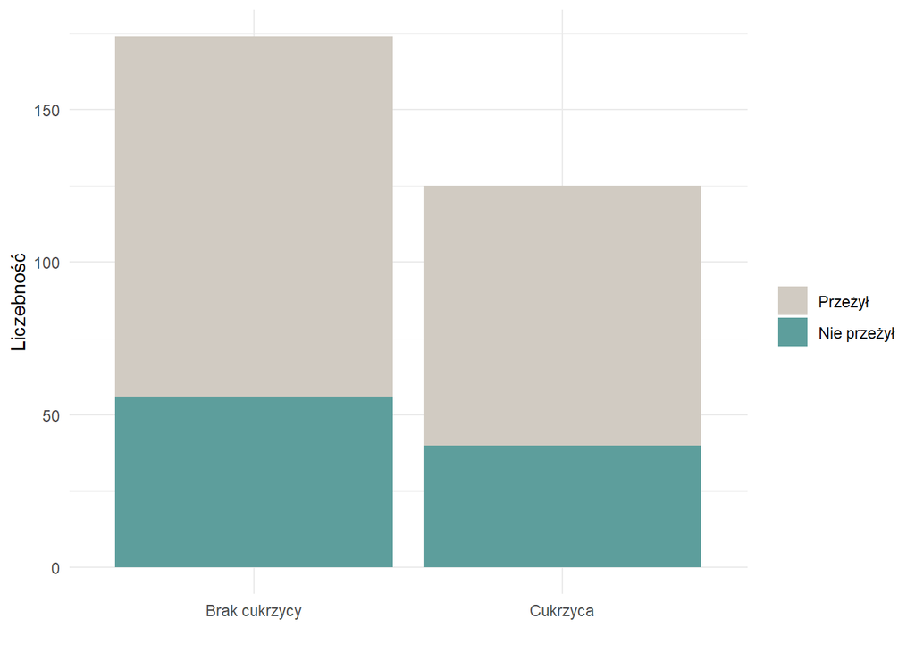

```r
heart %>%
  ggplot(aes(x = diabetes, fill = death_event)) +
  geom_bar() +
  labs(x = "", y = "Liczebność", fill = " ") +
  scale_fill_manual(labels = c("Przeżył", "Nie przeżył"), values = c("#D1CBC2", "#5D9E9C")) +
  scale_x_discrete(labels = c("0" = "Brak cukrzycy", "1" = "Cukrzyca")) +
  theme_minimal()
```

**Pokaż kod**

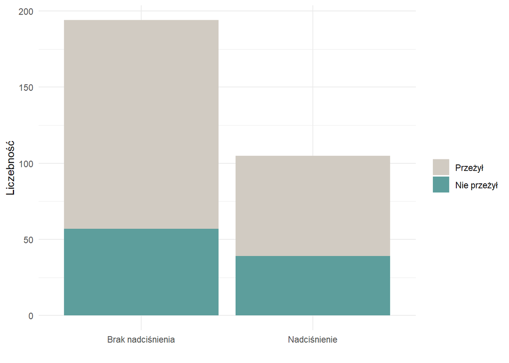

```r
heart %>%
  ggplot(aes(x = high_blood_pressure, fill = death_event)) +
  geom_bar() +
  labs(x = "", y = "Liczebność", fill = " ") +
  scale_fill_manual(labels = c("Przeżył", "Nie przeżył"), values = c("#D1CBC2", "#5D9E9C")) +
  scale_x_discrete(labels = c("0" = "Brak nadciśnienia", "1" = "Nadciśnienie")) +
  theme_minimal()
```

**Pokaż kod**

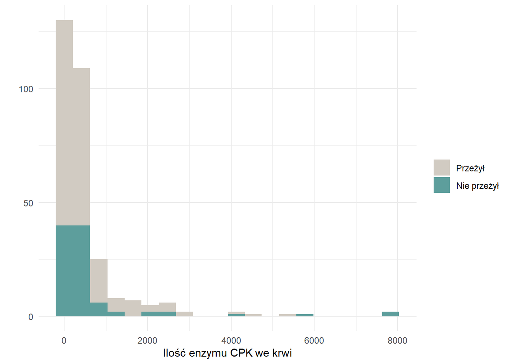

```r
heart %>%
  ggplot(aes(x = creatinine_phosphokinase, fill = death_event)) +
  geom_histogram(bins = 20) +
  labs(x = "Ilość enzymu CPK we krwi", y = "", fill = " ") +
  scale_fill_manual(labels = c("Przeżył", "Nie przeżył"), values = c("#D1CBC2", "#5D9E9C")) +
  theme_minimal()
```

**Pokaż kod**

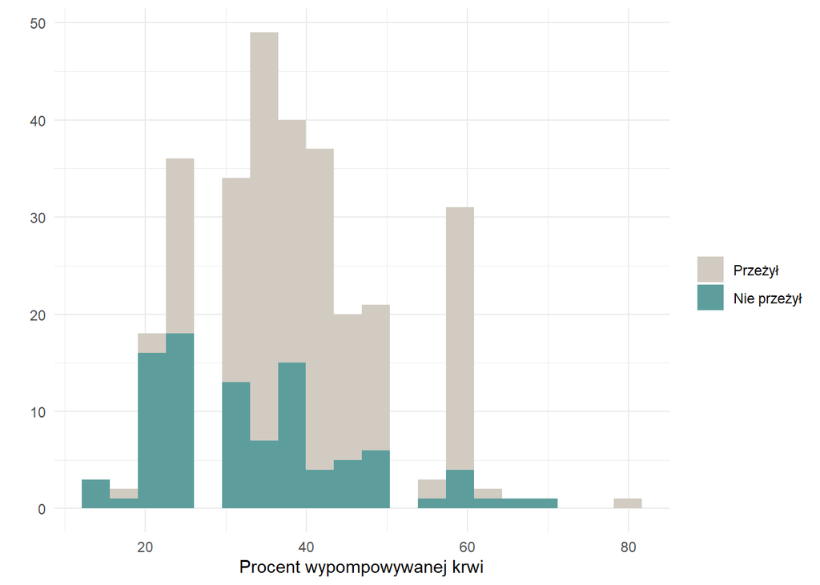

```r
heart %>%
  ggplot(aes(x = ejection_fraction, fill = death_event)) +
  geom_histogram(bins = 20) +
  labs(x = "Procent wypompowywanej krwi", y = "", fill = " ") +
  scale_fill_manual(labels = c("Przeżył", "Nie przeżył"), values = c("#D1CBC2", "#5D9E9C")) +
  theme_minimal()
```

**Pokaż kod**

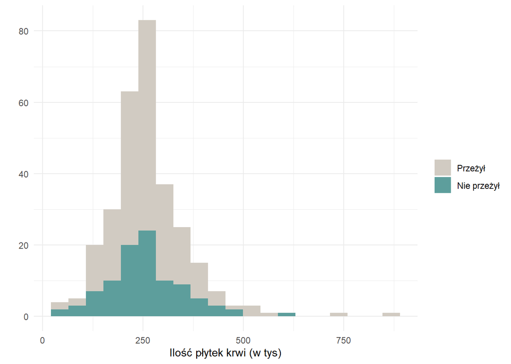

```r
heart %>%
  ggplot(aes(x = platelets/1000, fill = death_event)) +
  geom_histogram(bins = 20) +
  labs(x = "Ilość płytek krwi (w tys)", y = "", fill = " ") +
  scale_fill_manual(labels = c("Przeżył", "Nie przeżył"), values = c("#D1CBC2", "#5D9E9C")) +
  theme_minimal()
```

**Pokaż kod**

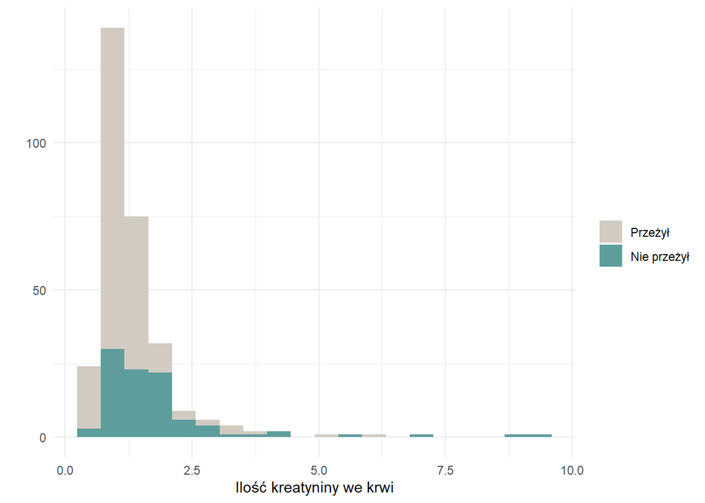

```r
heart %>%
  ggplot(aes(x = serum_creatinine, fill = death_event)) +
  geom_histogram(bins = 20) +
  labs(x = "Ilość kreatyniny we krwi", y = "", fill = " ") +
  scale_fill_manual(labels = c("Przeżył", "Nie przeżył"), values = c("#D1CBC2", "#5D9E9C")) +
  theme_minimal()
```

**Pokaż kod**

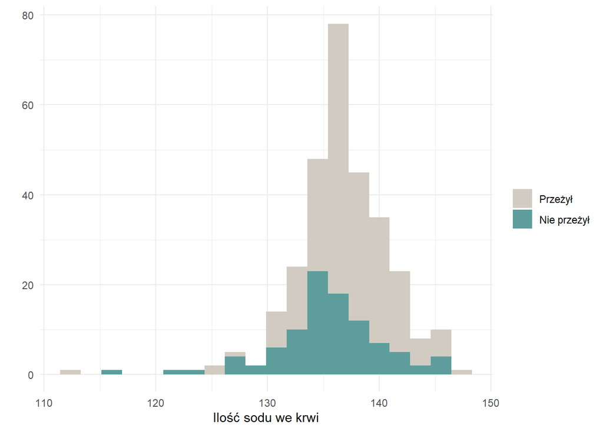

```r
heart %>%
  ggplot(aes(x = serum_sodium, fill = death_event)) +
  geom_histogram(bins = 20) +
  labs(x = "Ilość sodu we krwi", y = "", fill = " ") +
  scale_fill_manual(labels = c("Przeżył", "Nie przeżył"), values = c("#D1CBC2", "#5D9E9C")) +
  theme_minimal()
```

**Pokaż kod**

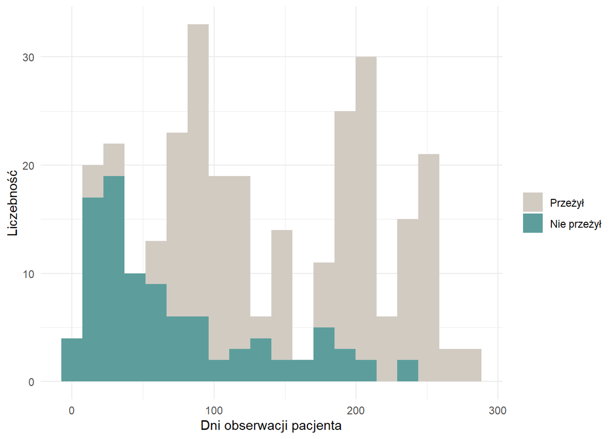

```r
heart %>%
  ggplot(aes(x = time, fill = death_event)) +
  geom_histogram(bins = 20) +
  labs(x = "Dni obserwacji pacjenta", y = "Liczebność", fill = " ") +
  scale_fill_manual(labels = c("Przeżył", "Nie przeżył"), values = c("#D1CBC2", "#5D9E9C")) +
  theme_minimal()
```

### Modelowanie

Wybranymi przeze mnie metodami klasyfikacji pacjentów są modele:

- regresji logistycznej z silnikiem `glmnet`
- lasu losowego z silnikiem `ranger`
- boosting z silnikiem `xgboost`
- drzewa decyzyjnego z silnikiem `rpart`
- SVM z silnikiem `kernlab`

Najpierw jednak sprawdzę liczebność obserwacji w grupach zmiennej objaśnianej `death_event`.

**Pokaż kod**

```r
count(heart, death_event) |>
  flextable()
```

Table 2: Liczebność poziomów zmiennej zależnej

| death_event | n |
| --- | --- |
| 0 | 203 |
| 1 | 96 |

W tabeli Table 2 wyraźnie widać, że zmienna jest niezrównoważona, dlatego konieczne będzie przeprowadzenie upsamplingu.

#### Podział na zbiór uczący i testowy

**Pokaż kod**

```r
h_split <- initial_split(heart, prop = .7)
h_train <- training(h_split)
h_test <- testing(h_split)
```

**Pokaż kod**

```r
#dla boostingu
bt_rec <- recipe(death_event~., data = h_train) %>%
  step_dummy(all_nominal_predictors()) %>%
  step_corr(all_numeric_predictors()) %>%
  step_zv(all_predictors()) %>%
  step_upsample(death_event)

#dla drzewa decyzyjnego

dt_rec <- recipe(death_event~., data = h_train) %>%
  step_corr(all_numeric_predictors()) %>%
  step_upsample(death_event)

#dla regresji logistycznej

lr_rec <- recipe(death_event~., data = h_train) %>%
  step_dummy(all_nominal_predictors()) %>%
  step_zv(all_predictors()) %>%
  step_corr(all_numeric_predictors()) %>%
  step_upsample(death_event)

#dla SVM
svm_rec <- recipe(death_event~., data = h_train) %>%
  step_dummy(all_nominal_predictors()) %>%
  step_zv(all_predictors()) %>%
  step_corr(all_numeric_predictors()) %>%
  step_normalize(all_numeric_predictors()) %>%
  step_YeoJohnson(all_numeric_predictors()) %>%
  step_upsample(death_event)

#dla lasu losowego
rf_rec <- recipe(death_event~., data = h_train) %>%
  step_zv(all_predictors()) %>%
  step_corr(all_numeric_predictors()) %>%
  step_upsample(death_event)
```

#### Boosting

**Pokaż kod**

```r
h_boost <- boost_tree(mode = "classification", tree_depth = tune(),
                      trees = tune(), learn_rate = tune(),
                      mtry = tune(), min_n = tune(), loss_reduction = tune(),
                      sample_size = tune(), stop_iter = tune()) %>%
  set_engine("xgboost")

control <- control_grid(save_pred = T)
folds <- vfold_cv(h_train, v = 10, repeats = 5)
metrics <- metric_set(bal_accuracy)


bt_wflow <- workflow() %>%
  add_recipe(bt_rec) %>%
  add_model(h_boost)

bt_param <- bt_wflow %>%
  extract_parameter_set_dials() %>%
  update(mtry = mtry(c(1,12)))

bt_grid <- grid_regular(bt_param, levels = 2)

bt_tuning <- tune_grid(object = bt_wflow, grid = bt_grid,
                       resamples = folds, metrics = metrics,
                       control = control, param_info = bt_param
)

boost_best <- show_best(bt_tuning, metric = "bal_accuracy")
fin_b_wflow <- finalize_workflow(bt_wflow, boost_best[1,])
boost_flow <- fit(fin_b_wflow, data = h_train)
pred_boost <- predict(boost_flow, h_test)
matrix_boost <- pred_boost %>%
  bind_cols(h_test) %>%
  conf_mat(truth = death_event, estimate = .pred_class)
```

#### Drzewo decyzyjne

**Pokaż kod**

```r
h_dt <- decision_tree(tree_depth = tune(), min_n = tune(),
                      cost_complexity = tune()) %>%
  set_engine("rpart") %>%
  set_mode("classification")

dt_wflow <- workflow() %>%
  add_recipe(dt_rec) %>%
  add_model(h_dt)

dt_param <- dt_wflow %>%
  extract_parameter_set_dials()

dt_grid <- grid_regular(dt_param, levels = 3)

dt_tuning <- tune_grid(object = dt_wflow, grid = dt_grid,
                       resamples = folds, metrics = metrics,
                       control = control, param_info = dt_param
)

dt_best <- show_best(dt_tuning, metric = "bal_accuracy")
fin_dt_wflow <- finalize_workflow(dt_wflow, dt_best[1,])
dt_flow <- fit(fin_dt_wflow, data = h_train)
pred_dt <- predict(dt_flow, h_test)
matrix_dt <- pred_dt %>%
  bind_cols(h_test) %>%
  conf_mat(truth = death_event, estimate = .pred_class)
```

#### Regresja logistyczna

**Pokaż kod**

```r
h_lr <- logistic_reg(penalty = tune(), mixture = tune()) %>%
  set_engine("glmnet")

lr_wflow <- workflow() %>%
  add_recipe(lr_rec) %>%
  add_model(h_lr)

lr_param <- lr_wflow %>%
  extract_parameter_set_dials()

lr_grid <- grid_regular(lr_param, levels = 3)

lr_tuning <- tune_grid(object = lr_wflow, grid = lr_grid,
                       resamples = folds, metrics = metrics,
                       control = control, param_info = lr_param )

lr_best <- show_best(lr_tuning, metric = "bal_accuracy")
fin_lr_wflow <- finalize_workflow(lr_wflow, lr_best[1,])
lr_flow <- fit(fin_lr_wflow, data = h_train)
pred_lr <- predict(lr_flow, h_test)
matrix_lr <- pred_lr %>%
  bind_cols(h_test) %>%
  conf_mat(truth = death_event, estimate = .pred_class)
```

#### SVM

**Pokaż kod**

```r
h_svm <- svm_linear(cost = tune(), margin = tune()) %>%
  set_engine("kernlab") %>%
  set_mode("classification")

svm_wflow <- workflow() %>%
  add_recipe(svm_rec) %>%
  add_model(h_svm)

svm_param <- svm_wflow %>%
  extract_parameter_set_dials()

svm_grid <- grid_regular(svm_param, levels = 2)

svm_tuning <- tune_grid(object = svm_wflow, grid = svm_grid,
                       resamples = folds, metrics = metrics,
                       control = control, param_info = svm_param )

svm_best <- show_best(svm_tuning, metric = "bal_accuracy")
fin_svm_wflow <- finalize_workflow(svm_wflow, svm_best[1,])
svm_flow <- fit(fin_svm_wflow, data = h_train)
pred_svm <- predict(svm_flow, h_test)
matrix_svm <- pred_svm %>%
  bind_cols(h_test) %>%
  conf_mat(truth = death_event, estimate = .pred_class)
```

#### Drzewo losowe

**Pokaż kod**

```r
h_rf <- rand_forest(mtry = tune(),trees = tune(), min_n = tune()) %>%
                        set_engine("ranger") %>%
                        set_mode("classification")

rf_wflow <- workflow() %>%
  add_recipe(rf_rec) %>%
  add_model(h_rf)

rf_param <- rf_wflow %>%
  extract_parameter_set_dials()  %>%
  update(mtry = mtry(c(1,12)))

rf_grid <- grid_regular(rf_param, levels = 3)

rf_tuning <- tune_grid(object = rf_wflow, grid = rf_grid,
                       resamples = folds, metrics = metrics,
                       control = control, param_info = rf_param )

rf_best <- show_best(rf_tuning, metric = "bal_accuracy")
fin_rf_wflow <- finalize_workflow(rf_wflow, rf_best[1,])
rf_flow <- fit(fin_rf_wflow, data = h_train)
pred_rf <- predict(rf_flow, h_test)
matrix_rf <- pred_rf %>%
  bind_cols(h_test) %>%
  conf_mat(truth = death_event, estimate = .pred_class)
```

### Wyniki

#### Macierze konfuzji

##### Macierz konfuzji boostingu

**Pokaż kod**

```r
matrix_boost
```

```
          Truth
Prediction  0  1
         0 55 10
         1  7 18
```

##### Macierz konfuzji drzewa decyzyjnego

**Pokaż kod**

```r
matrix_dt
```

```
          Truth
Prediction  0  1
         0 53  6
         1  9 22
```

##### Macierz konfuzji regresji logistycznej

**Pokaż kod**

```r
matrix_lr
```

```
          Truth
Prediction  0  1
         0 52  2
         1 10 26
```

##### Macierz konfuzji SVM

**Pokaż kod**

```r
matrix_svm
```

```
          Truth
Prediction  0  1
         0 52  3
         1 10 25
```

##### Macierz konfuzji lasu losowego

**Pokaż kod**

```r
matrix_rf
```

```
          Truth
Prediction  0  1
         0 58  6
         1  4 22
```

**Pokaż kod**

```r
summ_boost <- summary(matrix_boost)
summ_dt <- summary(matrix_dt)
summ_lr <- summary(matrix_lr)
summ_svm <- summary(matrix_svm)
summ_rf <- summary(matrix_rf)
#| label: tbl-metric
#| tbl-cap: Metryki modeli
wyniki <- data.frame(summ_boost$.metric, round(summ_boost$.estimate, 4),
                     round(summ_dt$.estimate, 4),round(summ_lr$.estimate, 4),
                     round(summ_svm$.estimate,4), round(summ_rf$.estimate,4))
wyniki %>%
  flextable() %>%
  set_header_labels(values = c("Metryka", "Boosting",
                               "Drzewo decyzyjne", "Regresja logistyczna",
                               "SVM", "Las losowy")) %>%
  theme_zebra()
```

| Metryka | Boosting | Drzewo decyzyjne | Regresja logistyczna | SVM | Las losowy |
| --- | --- | --- | --- | --- | --- |
| accuracy | 0.8111 | 0.8333 | 0.8667 | 0.8556 | 0.8889 |
| kap | 0.5460 | 0.6223 | 0.7115 | 0.6846 | 0.7356 |
| sens | 0.8871 | 0.8548 | 0.8387 | 0.8387 | 0.9355 |
| spec | 0.6429 | 0.7857 | 0.9286 | 0.8929 | 0.7857 |
| ppv | 0.8462 | 0.8983 | 0.9630 | 0.9455 | 0.9062 |
| npv | 0.7200 | 0.7097 | 0.7222 | 0.7143 | 0.8462 |
| mcc | 0.5478 | 0.6241 | 0.7251 | 0.6947 | 0.7366 |
| j_index | 0.5300 | 0.6406 | 0.7673 | 0.7316 | 0.7212 |
| bal_accuracy | 0.7650 | 0.8203 | 0.8836 | 0.8658 | 0.8606 |
| detection_prevalence | 0.7222 | 0.6556 | 0.6000 | 0.6111 | 0.7111 |
| precision | 0.8462 | 0.8983 | 0.9630 | 0.9455 | 0.9062 |
| recall | 0.8871 | 0.8548 | 0.8387 | 0.8387 | 0.9355 |
| f_meas | 0.8661 | 0.8760 | 0.8966 | 0.8889 | 0.9206 |

Biorąc pod uwagę wszystkie metryki, najlepiej wypadł las losowy, natomiast na podstawie zbalansowanej dokładności najlepsza okazała się regresja logistyczna.